# AMR-Wind ABL Boundary I/O

Wind farm simulations typically require ABL inflow conditions. As such, a precursor ABL simulation is often performed to collect inflow conditions for the wind farm. AMR-Wind leverages NetCDF to collect ABL inflow variables at each time step and write the data to a file. This file can then be read during a wind farm simulation to populate the inflow.

Note

- Currently, it is only possible to write xlo and ylo boundaries.
- Inflow conditions are linearly interpolated between output times.
- The time for the simulation that is reading the inflow file must be entirely contained within the inflow times.
- The simulation reading the inflow file must have the same grid resolution at the boundaries.

## Generating the inflow file from an ABL simulation

The following section can be added to the input file to generate an inflow file during an ABL simulation:

```
ABL.bndry_file = "bndry_file.nc"
ABL.bndry_io_mode = 0
ABL.bndry_planes = ylo xlo
ABL.bndry_output_start_time = 2.0
ABL.bndry_var_names = velocity temperature
```

In the case of using the OneEqKsgsM84 model the tke field is also needed.

```
ABL.bndry_var_names = velocity temperature tke
```

## Using an inflow file in an ABL simulation

The following section can be added to the input file to read an inflow file to populate the boundary conditions:

```
ABL.bndry_file = "../orig/bndry_file.nc"
ABL.bndry_io_mode = 1
ABL.bndry_var_names = velocity temperature
```

Again, In the case of using the OneEqKsgsM84 model the tke field is also needed.

```
ABL.bndry_var_names = velocity temperature tke
```

The boundary conditions need to be adjusted from periodic to inflow/outflow. The following lines show the changes that need to be made to the input file for the x coordinate (similar change for y coordinate when needed):

```
geometry.is_periodic           = 0 1 0                          # Periodicity x y z (0/1)

xlo.type = "mass_inflow"
xlo.density = 1.0
xhi.type = "pressure_outflow"
```

## Inflow file structure

The inflow file is written by the NetCDF library in the following structure:

> - Top level contains the data common to all the groups (title, dimensions, time)
> - Mid level contains the groups of planes: Each plane (e.g. xlo) is assigned a group at this level. It contains variables such as the plane normal and perpendicular directions.
> - Bottom levels contains groups of AMR levels, i.e. the levels associated with each plane: Each AMR level is assigned a group (e.g. “level_0”, “level_1”, etc) containing the variable dimensions and the inflow variables (e.g. velocity) associated with that level.

For a multi-level file, ncdump -h <file> provides:

```
netcdf bndry_file {
dimensions:
	sdim = 1 ;
	pdim = 2 ;
	vdim = 3 ;
	nt = UNLIMITED ; // (7 currently)
variables:
	double time(nt) ;

// global attributes:
		:title = "ABL boundary planes" ;

group: xlo {
  variables:
  	int normal ;
  	int side ;
  	int perpendicular(pdim) ;

  group: level_0 {
    dimensions:
    	nx = 48 ;
    	ny = 48 ;
    	nz = 48 ;
    variables:
    	double lengths(pdim) ;
    	double lo(pdim) ;
    	double hi(pdim) ;
    	double dx(pdim) ;
    	double velocity(nt, ny, nz, vdim) ;
    	double temperature(nt, ny, nz) ;
    } // group level_0

  group: level_1 {
    dimensions:
    	nx = 96 ;
    	ny = 96 ;
    	nz = 56 ;
    variables:
    	double lengths(pdim) ;
    	double lo(pdim) ;
    	double hi(pdim) ;
    	double dx(pdim) ;
    	double velocity(nt, ny, nz, vdim) ;
    	double temperature(nt, ny, nz) ;
    } // group level_1
  } // group xlo

group: ylo {
  variables:
  	int normal ;
  	int side ;
  	int perpendicular(pdim) ;

  group: level_0 {
    dimensions:
    	nx = 48 ;
    	ny = 48 ;
    	nz = 48 ;
    variables:
    	double lengths(pdim) ;
    	double lo(pdim) ;
    	double hi(pdim) ;
    	double dx(pdim) ;
    	double velocity(nt, nx, nz, vdim) ;
    	double temperature(nt, nx, nz) ;
    } // group level_0

  group: level_1 {
    dimensions:
    	nx = 96 ;
    	ny = 96 ;
    	nz = 56 ;
    variables:
    	double lengths(pdim) ;
    	double lo(pdim) ;
    	double hi(pdim) ;
    	double dx(pdim) ;
    	double velocity(nt, nx, nz, vdim) ;
    	double temperature(nt, nx, nz) ;
    } // group level_1
  } // group ylo
}
```

The inflow file can be inspected with Python as such:

```python
from netCDF4 import Dataset
import matplotlib.pyplot as plt
```

Load the file and inspect the top level

```python
rg = Dataset("bndry_file.nc", "r")
print(rg)
```

```
<class 'netCDF4._netCDF4.Dataset'>
root group (NETCDF4 data model, file format HDF5):
    title: ABL boundary planes
    dimensions(sizes): pdim(2), sdim(1), vdim(3), nt(7)
    variables(dimensions): float64 time(nt)
    groups: xlo, ylo
```

Looping through the planes

```python
for grp in rg.groups:
    print(f"""Accessing {grp}:""")
    print(rg.groups[grp])
```

```
Accessing xlo:
<class 'netCDF4._netCDF4.Group'>
group /xlo:
    dimensions(sizes):
    variables(dimensions): int32 normal(sdim), int32 side(sdim), int32 perpendicular(pdim)
    groups: level_0, level_1
Accessing ylo:
<class 'netCDF4._netCDF4.Group'>
group /ylo:
    dimensions(sizes):
    variables(dimensions): int32 normal(sdim), int32 side(sdim), int32 perpendicular(pdim)
    groups: level_0, level_1
```

Inspect the output times

```python
print(rg.variables["time"][:])
```

```
[2.  2.5 3.  3.5 4.  4.5 5. ]
```

Looping through the AMR levels in a given plane

```python
plane = "ylo"
for grp in rg.groups[plane].groups:
    print(f"""Accessing {grp} in plane {plane}:""")
    print(rg.groups[plane].groups[grp])
```

```
Accessing level_0 in plane ylo:
<class 'netCDF4._netCDF4.Group'>
group /ylo/level_0:
    dimensions(sizes): nx(48), ny(48), nz(48)
    variables(dimensions): float64 lengths(pdim), float64 lo(pdim), float64 hi(pdim), float64 dx(pdim), float64 velocity(nt,nx,nz,vdim), float64 temperature(nt,nx,nz)
    groups:
Accessing level_1 in plane ylo:
<class 'netCDF4._netCDF4.Group'>
group /ylo/level_1:
    dimensions(sizes): nx(96), ny(96), nz(56)
    variables(dimensions): float64 lengths(pdim), float64 lo(pdim), float64 hi(pdim), float64 dx(pdim), float64 velocity(nt,nx,nz,vdim), float64 temperature(nt,nx,nz)
    groups:
```

An example of plotting the data in the different planes and levels

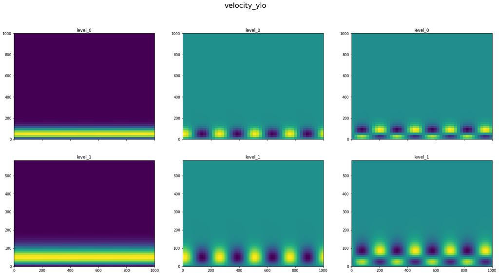

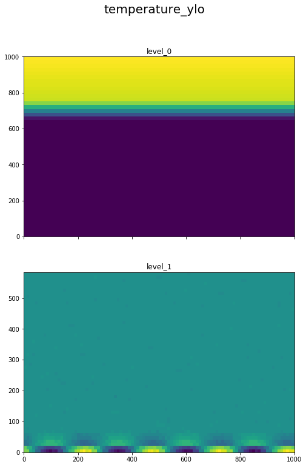

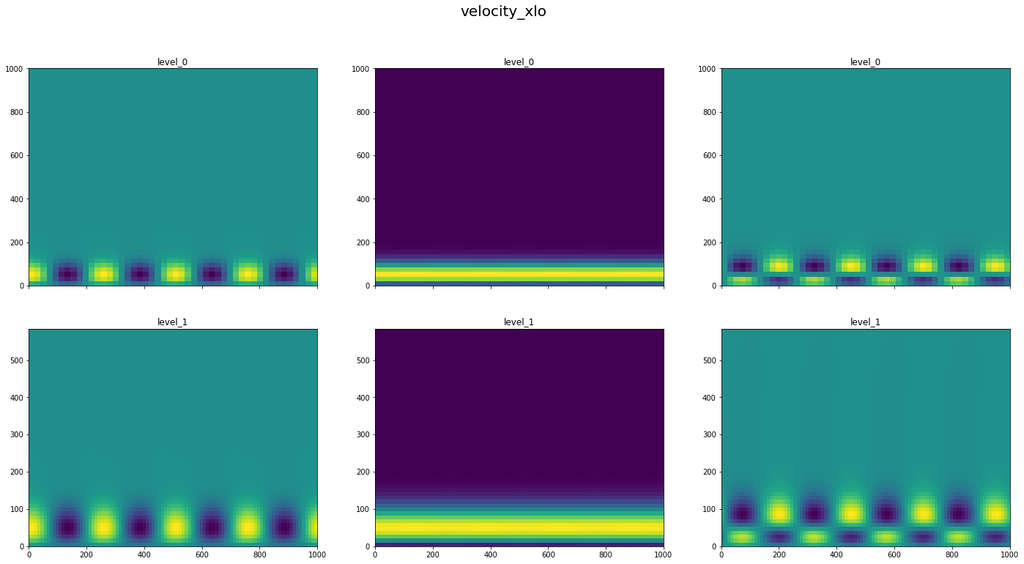

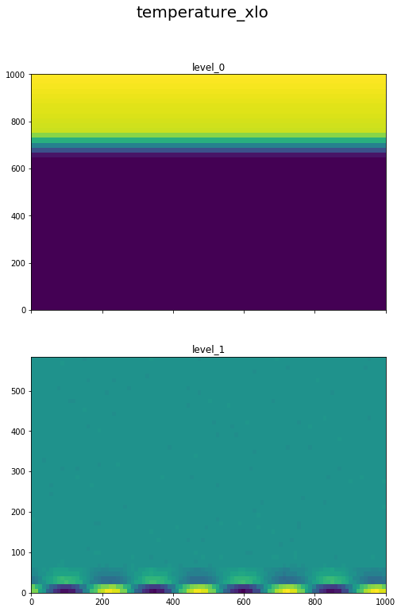

```python
def plot_field(plane, name):
    nlevels = len(plane.groups)
    shp = (plane.groups["level_0"].variables[name][:]).shape
    if len(shp) == 4:
        ncomp = shp[-1]
    else:
        ncomp = 1
    fig, axs = plt.subplots(nrows=nlevels, ncols=ncomp, sharex=True, figsize=(8*ncomp,6*nlevels), squeeze=False)
    fig.suptitle(f"{name}_{plane.name}", fontsize=20)
    for component in range(ncomp):
        for i, lev in enumerate(plane.groups):
            fld = plane.groups[lev].variables[name][:]
            lo = plane.groups[lev].variables["lo"][:]
            hi = plane.groups[lev].variables["hi"][:]

            if ncomp == 1:
                arr = fld[0, :, :].T
            else:
                arr = fld[0, :, :, component].T
            axs[i, component].imshow(
                arr,
                extent=[lo[0], hi[0], lo[1], hi[1]],
                origin="lower",
                aspect="auto",
            )
            axs[i, component].set_title(lev)
    plt.savefig(f"{name}_{plane.name}.png")

for plane in ["ylo", "xlo"]:

    plot_field(rg.groups[plane], "velocity")
    plot_field(rg.groups[plane], "temperature")
```